# R para ciencia de datos ejercicios 4

Noelí D’Alessio

5/2/2020

```r
library(tidyverse)
library(dplyr)
library(datos)
```

# 5.7.1 Ejercicios

### 2.¿Qué avión (codigo_cola) tiene el peor registro de tiempo?

Considero que el promedio de retraso, y la cantidad de vuelos no retrasados o cancelados son posibles metricas para estimar el peor registro de tiempo.

```r
vuelos %>%
    filter(!is.na(codigo_cola)) %>%
    mutate(vuelos_a_tiempo = !is.na(atraso_salida) & (atraso_salida <= 0)) %>%
    group_by(codigo_cola) %>%
    summarise(
      vuelos_a_tiempo = mean(vuelos_a_tiempo),
      n = n()
    ) %>%
    filter(n >= 20) %>%
    filter(min_rank(vuelos_a_tiempo) == 1)
```

```
## # A tibble: 1 x 3
##   codigo_cola vuelos_a_tiempo     n
##   <chr>                 <dbl> <int>
## 1 N787SA                  0.1    20
```

Filtramos aquellos vuelos que hayan volado al menos 20 veces. 20 es , aproximadamente, la cantidad de vuelos que realizó al menos el 25% de los aviones.

```r
quantile(count(vuelos, codigo_cola)$n)
```

```
##   0%  25%  50%  75% 100%
##    1   23   54  110 2512
```

```r
vuelos %>%
    filter(!is.na(codigo_cola)) %>%
    group_by(codigo_cola) %>%
    summarise(atraso_llegada = mean(atraso_llegada), n = n()) %>%
    filter(n >= 20) %>%
    filter(min_rank(desc(atraso_llegada)) == 1)
```

```
## # A tibble: 1 x 3
##   codigo_cola atraso_llegada     n
##   <chr>                <dbl> <int>
## 1 N203FR                59.1    41
```

### 3. ¿A qué hora del día deberías volar si quieres evitar lo más posible los retrasos?

```r
vuelos %>%
  group_by(hora) %>%
  summarise(atraso_llegada = mean(atraso_llegada, na.rm = TRUE)) %>%
  arrange(atraso_llegada)
```

```
## # A tibble: 20 x 2
##     hora atraso_llegada
##    <dbl>          <dbl>
##  1     7         -5.30
##  2     5         -4.80
##  3     6         -3.38
##  4     9         -1.45
##  5     8         -1.11
##  6    10          0.954
##  7    11          1.48
##  8    12          3.49
##  9    13          6.54
## 10    14          9.20
## 11    23         11.8
## 12    15         12.3
## 13    16         12.6
## 14    18         14.8
## 15    22         16.0
## 16    17         16.0
## 17    19         16.7
## 18    20         16.7
## 19    21         18.4
## 20     1        NaN
```

### 4. Para cada destino, calcula los minutos totales de demora. Para cada vuelo, calcula la proporción de la demora total para su destino.

```r
vuelos %>%
  group_by(destino) %>%
  mutate(
    atraso_total = sum(atraso_llegada, na.rm = TRUE),
    atraso_proporcion = atraso_llegada/atraso_total) %>%
  select(destino, mes, dia, horario_salida, aerolinea, vuelo, atraso_total, atraso_proporcion) %>%
  arrange(destino, desc(atraso_proporcion))
```

```
## # A tibble: 336,776 x 8
## # Groups:   destino [105]
##    destino   mes   dia horario_salida aerolinea vuelo atraso_total
##    <chr>   <int> <int>          <int> <chr>     <int>        <dbl>
##  1 ABQ         7    22           2145 B6         1505         1113
##  2 ABQ        12    14           2223 B6           65         1113
##  3 ABQ        10    15           2146 B6           65         1113
##  4 ABQ         7    23           2206 B6         1505         1113
##  5 ABQ        12    17           2220 B6           65         1113
##  6 ABQ         7    10           2025 B6         1505         1113
##  7 ABQ         7    30           2212 B6         1505         1113
##  8 ABQ         7    28           2038 B6         1505         1113
##  9 ABQ        12     8           2049 B6           65         1113
## 10 ABQ         9     2           2212 B6         1505         1113
## # ... with 336,766 more rows, and 1 more variable: atraso_proporcion <dbl>
```

Sin embargo, también podemos considerar “vuelo” como al número de vuelo, que es un código que utiliza la aerolínea por un servicio de ruta que ofrece. El número de vuelo se encuentra en flights flight, pero la combinacion con la aerolinea seria ademas flights aerolinea.

```r
vuelos %>%
  filter(atraso_llegada > 0) %>%
  group_by(destino, origen, aerolinea, vuelo) %>%
  summarise(atraso_llegada = sum(atraso_llegada)) %>%
  group_by(destino) %>%
  mutate(atraso_proporcion = atraso_llegada/sum(atraso_llegada))%>%
  arrange(destino, desc(atraso_proporcion)) %>%
  select(aerolinea, vuelo, origen, destino, atraso_proporcion)
```

```
## # A tibble: 8,834 x 5
## # Groups:   destino [103]
##    aerolinea vuelo origen destino atraso_proporcion
##    <chr>     <int> <chr>  <chr>               <dbl>
##  1 B6         1505 JFK    ABQ                0.567
##  2 B6           65 JFK    ABQ                0.433
##  3 B6         1191 JFK    ACK                0.475
##  4 B6         1491 JFK    ACK                0.414
##  5 B6         1291 JFK    ACK                0.0898
##  6 B6         1195 JFK    ACK                0.0208
##  7 EV         4309 EWR    ALB                0.174
##  8 EV         4271 EWR    ALB                0.137
##  9 EV         4117 EWR    ALB                0.0951
## 10 EV         4088 EWR    ALB                0.0865
## # ... with 8,824 more rows
```

### 5.Los retrasos suelen estar temporalmente correlacionados: incluso una vez que el problema que causó el retraso inicial se ha resuelto, los vuelos posteriores se retrasan para permitir que salgan los vuelos anteriores. Usando lag(), explora cómo el retraso de un vuelo está relacionado con el retraso del vuelo inmediatamente anterior.

```r
atrasos_lagged <-
    vuelos %>%
    arrange(origen, mes, dia, horario_salida) %>%
    group_by(origen) %>%
    mutate(atraso_salida_lag = lag(atraso_salida)) %>%
    filter(!is.na(atraso_salida), !is.na(atraso_salida_lag)) %>%
    select(mes, dia, horario_salida, atraso_salida, atraso_salida_lag)
```

La funcion anterior nos devuelve un data frame con una nueva variable: “atraso_salida_lag”. Esta variable guarda el atraso del vuelo anterior. Para lograr esta variable agrupamos por origen, para que nos devuelva el retraso anterior que hubo en el mismo aeropuerto.

Para graficarlo:

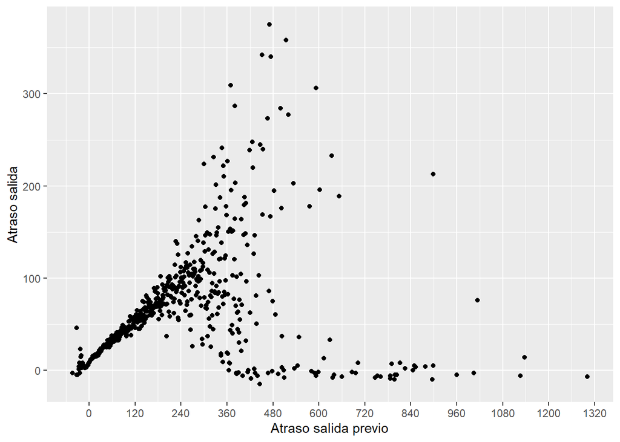

```r
atrasos_lagged %>%
    group_by(atraso_salida_lag) %>%
    summarise(promedio_atraso_salida = mean(atraso_salida)) %>%

    ggplot(aes(y = promedio_atraso_salida, x = atraso_salida_lag)) +
    geom_point() +
    scale_x_continuous(breaks = seq(0, 1500,  by = 120)) +
    labs(y = "Atraso salida", x = "Atraso salida previo")
```

### 6. Mira cada destino. ¿Puedes encontrar vuelos sospechosamente rápidos? (es decir, vuelos que representan un posible error de entrada de datos). Calcula el tiempo en el aire de un vuelo relativo al vuelo más corto a ese destino. ¿Cuáles vuelos se retrasaron más en el aire?

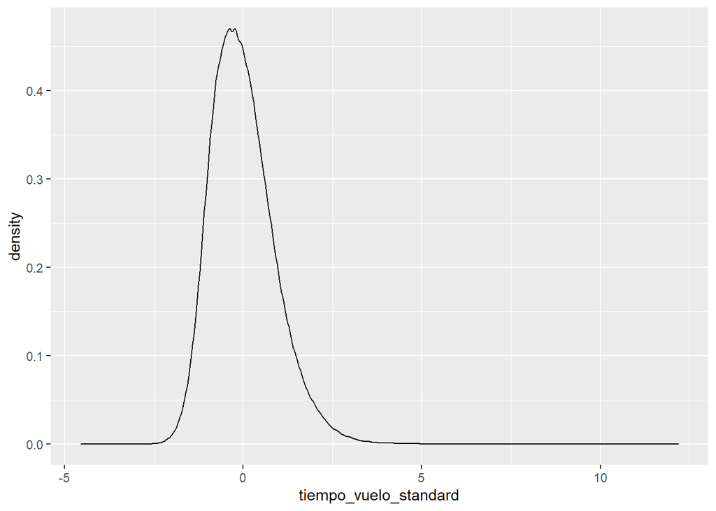

```r
vuelos_estandarizados<-
    vuelos %>%
    filter(!is.na(tiempo_vuelo)) %>%
    group_by(destino, origen) %>%
    mutate(
      tiempo_vuelo_promedio = mean(tiempo_vuelo),
      tiempo_vuelo_ds = sd(tiempo_vuelo),
      n = n()
    ) %>%
    ungroup() %>%
    mutate(tiempo_vuelo_standard = (tiempo_vuelo - tiempo_vuelo_promedio) / (tiempo_vuelo_ds + 1))

ggplot(vuelos_estandarizados, aes(x = tiempo_vuelo_standard)) +
    geom_density()
```

```r
vuelos_estandarizados %>%
    arrange(tiempo_vuelo_standard) %>%
    select(mes, dia, origen, destino, vuelo, aerolinea, tiempo_vuelo,
           tiempo_vuelo_promedio, tiempo_vuelo_standard) %>%
    head(10) %>%
    print(width = Inf)
```

```
## # A tibble: 10 x 9
##      mes   dia origen destino vuelo aerolinea tiempo_vuelo tiempo_vuelo_promedio
##    <int> <int> <chr>  <chr>   <int> <chr>            <dbl>                 <dbl>
##  1     5    25 LGA    ATL      1499 DL                  65                 114.
##  2     7     2 EWR    MSP      4667 EV                  93                 151.
##  3     5    13 EWR    GSP      4292 EV                  55                  93.2
##  4     3    23 EWR    BNA      3805 EV                  70                 115.
##  5     9    29 EWR    CVG      4687 EV                  62                  96.1
##  6    11    10 JFK    BUF      2002 B6                  38                  57.1
##  7     1    12 LGA    PBI      1902 DL                 105                 146.
##  8     7     3 JFK    SEA       161 DL                 275                 329.
##  9     4    28 LGA    PIT      5486 EV                  40                  57.7
## 10     3    25 JFK    ROC        30 B6                  35                  51.9
##    tiempo_vuelo_standard
##                    <dbl>
##  1                 -4.56
##  2                 -4.46
##  3                 -4.20
##  4                 -3.73
##  5                 -3.60
##  6                 -3.38
##  7                 -3.34
##  8                 -3.34
##  9                 -3.15
## 10                 -3.10
```

En este caso, el vuelo mas rápido es el vuelo 1499 de Delta que viaja de La Guardia Airport a Atlanta. El promedio de este viaje, es 113 minutos y esta vuelo tarda 65 minutos. Esto representa un desvío standard de -4.5. Dicha diferencia puede deberse a un error en los datos, pero tambien puede deberse a outliers que afectan la media y el desvio standard.

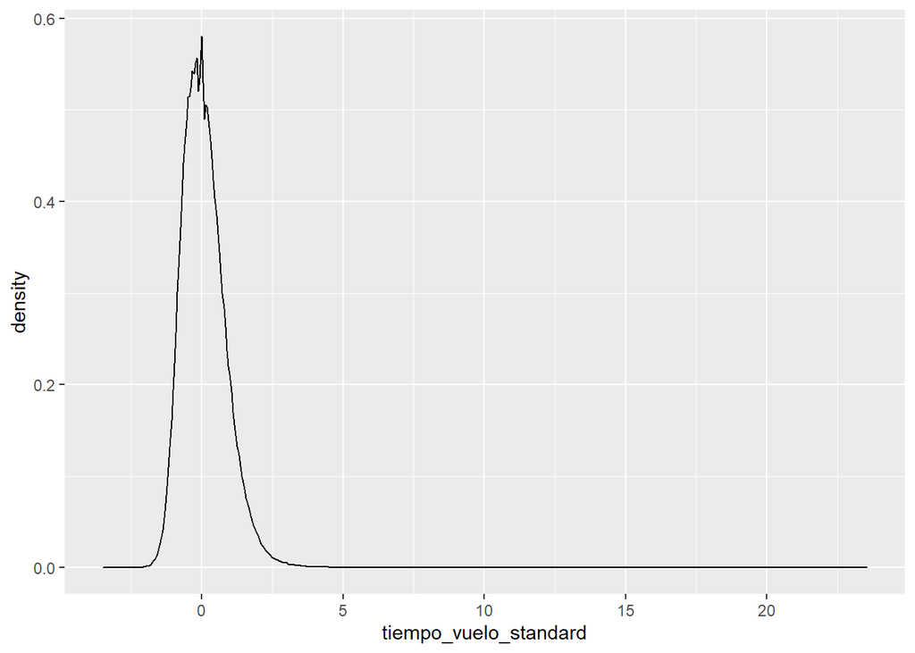

```r
vuelos_estandarizados2 <-
    vuelos %>%
    filter(!is.na(tiempo_vuelo)) %>%
    group_by(destino, origen) %>%
    mutate(
      tiempo_vuelo_mediana = median(tiempo_vuelo),
      tiempo_vuelo_iqr = IQR(tiempo_vuelo),
      n = n(),
      tiempo_vuelo_standard = (tiempo_vuelo - tiempo_vuelo_mediana) / tiempo_vuelo_iqr
    ) %>%
  ungroup()

ggplot(vuelos_estandarizados2, aes(x = tiempo_vuelo_standard)) +
    geom_density()
```

```r
  vuelos_estandarizados2 %>%
      arrange(tiempo_vuelo_standard) %>%
      select(mes, dia, origen, destino, vuelo, aerolinea, tiempo_vuelo,
           tiempo_vuelo_mediana, tiempo_vuelo_iqr, tiempo_vuelo_standard) %>%
      head() %>%
      print(width = Inf)
```

```
## # A tibble: 6 x 10
##     mes   dia origen destino vuelo aerolinea tiempo_vuelo tiempo_vuelo_mediana
##   <int> <int> <chr>  <chr>   <int> <chr>            <dbl>                <dbl>
## 1     7     2 EWR    MSP      4667 EV                  93                  149
## 2     5    25 LGA    ATL      1499 DL                  65                  112
## 3     3     2 LGA    BOS      2132 US                  21                   37
## 4     3    25 JFK    ROC        30 B6                  35                   51
## 5    11    10 JFK    BUF      2002 B6                  38                   57
## 6     5    13 EWR    GSP      4292 EV                  55                   92
##   tiempo_vuelo_iqr tiempo_vuelo_standard
##              <dbl>                 <dbl>
## 1               16                 -3.5
## 2               14                 -3.36
## 3                5                 -3.2
## 4                5                 -3.2
## 5                6                 -3.17
## 6               12                 -3.08
```

- Vuelos más rápidos de acuerdo a la velocidad (mph):

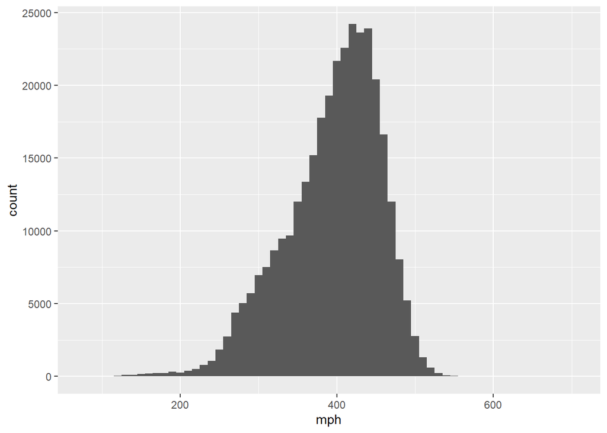

```r
vuelos %>%
      mutate(mph = distancia / (tiempo_vuelo/60)) %>%
      ggplot(aes(x = mph)) +
      geom_histogram(binwidth = 10)
```

```r
vuelos %>%
    mutate(mph = distancia / (tiempo_vuelo/60)) %>%
    arrange(desc(mph)) %>%
    select(mph, vuelo, aerolinea, mes, dia, horario_salida, atraso_salida, atraso_llegada) %>%
    head(5)
```

```
## # A tibble: 5 x 8
##     mph vuelo aerolinea   mes   dia horario_salida atraso_salida atraso_llegada
##   <dbl> <int> <chr>     <int> <int>          <int>         <dbl>          <dbl>
## 1  703.  1499 DL            5    25           1709             9            -14
## 2  650.  4667 EV            7     2           1558            45             26
## 3  648   4292 EV            5    13           2040            15             -1
## 4  641.  3805 EV            3    23           1914             4              2
## 5  591.  1902 DL            1    12           1559            -1            -28
```

La última pregunta de este punto es cuáles son los vuelos más retrasados.

```r
vuelos_retrasados <-
    vuelos %>%
    group_by(origen, destino) %>%
    mutate(
      tiempo_vuelo_minimo = min(tiempo_vuelo, na.rm = TRUE),
      tiempo_vuelo_atraso = tiempo_vuelo - tiempo_vuelo_minimo,
      tiempo_vuelo_porcentaje = tiempo_vuelo_atraso / tiempo_vuelo_minimo * 100
    )

vuelos_retrasados
```

```
## # A tibble: 336,776 x 22
## # Groups:   origen, destino [224]
##     anio   mes   dia horario_salida salida_programa~ atraso_salida
##    <int> <int> <int>          <int>            <int>         <dbl>
##  1  2013     1     1            517              515             2
##  2  2013     1     1            533              529             4
##  3  2013     1     1            542              540             2
##  4  2013     1     1            544              545            -1
##  5  2013     1     1            554              600            -6
##  6  2013     1     1            554              558            -4
##  7  2013     1     1            555              600            -5
##  8  2013     1     1            557              600            -3
##  9  2013     1     1            557              600            -3
## 10  2013     1     1            558              600            -2
## # ... with 336,766 more rows, and 16 more variables: horario_llegada <int>,
## #   llegada_programada <int>, atraso_llegada <dbl>, aerolinea <chr>,
## #   vuelo <int>, codigo_cola <chr>, origen <chr>, destino <chr>,
## #   tiempo_vuelo <dbl>, distancia <dbl>, hora <dbl>, minuto <dbl>,
## #   fecha_hora <dttm>, tiempo_vuelo_minimo <dbl>, tiempo_vuelo_atraso <dbl>,
## #   tiempo_vuelo_porcentaje <dbl>
```

```r
vuelos_retrasados %>%
    arrange(desc(tiempo_vuelo_atraso)) %>%
    select(tiempo_vuelo_atraso, tiempo_vuelo_porcentaje, vuelo, aerolinea, mes, dia, horario_salida, tiempo_vuelo) %>%
    head() %>%
    print(width = Inf)
```

```
## # A tibble: 6 x 10
## # Groups:   origen, destino [5]
##   origen destino tiempo_vuelo_atraso tiempo_vuelo_porcentaje vuelo aerolinea
##   <chr>  <chr>                 <dbl>                   <dbl> <int> <chr>
## 1 JFK    SFO                     189                    62.8   841 DL
## 2 JFK    LAX                     165                    60     426 DL
## 3 JFK    EGE                     163                    74.4   575 AA
## 4 JFK    LAX                     147                    53.5    17 DL
## 5 LGA    DEN                     145                    78.0   745 UA
## 6 EWR    LAS                     143                    55.9   587 UA
##     mes   dia horario_salida tiempo_vuelo
##   <int> <int>          <int>        <dbl>
## 1     7    28           1727          490
## 2    11    22           1812          440
## 3     1    28           1806          382
## 4     7    10           1814          422
## 5     9    10           1513          331
## 6    11    22           2142          399
```

### 7. Encuentra todos los destinos que son volados por al menos dos operadores. Usa esta información para clasificar a las aerolíneas.

Primer paso: calcular

```r
vuelos %>%
  # Cuántos aeropuertos reciben vuelos de al menos dos aerolíneas

  group_by(destino) %>%
  mutate(n_aerolineas = n_distinct(aerolinea)) %>%
  filter(n_aerolineas > 1) %>%

  # Ranking de cantidad de destinos por aerolínea

  group_by(aerolinea) %>%
  summarise(n_destinos = n_distinct(destino)) %>%
  arrange(desc(n_destinos))
```

```
## # A tibble: 16 x 2
##    aerolinea n_destinos
##    <chr>          <int>
##  1 EV                51
##  2 9E                48
##  3 UA                42
##  4 DL                39
##  5 B6                35
##  6 AA                19
##  7 MQ                19
##  8 WN                10
##  9 OO                 5
## 10 US                 5
## 11 VX                 4
## 12 YV                 3
## 13 FL                 2
## 14 AS                 1
## 15 F9                 1
## 16 HA                 1
```

```r
filter(aerolineas, aerolinea == "EV")
```

```
## # A tibble: 1 x 2
##   aerolinea nombre
##   <chr>     <chr>
## 1 EV        ExpressJet Airlines Inc.
```

### Para cada avión, cuenta el número de vuelos antes del primer retraso de más de 1 hora.

(Tendré en cuenta el atraso_salida)

```r
vuelos %>%
    select(codigo_cola, anio, mes, dia, atraso_salida) %>%
    filter(!is.na(atraso_salida)) %>%
    arrange(codigo_cola, anio, mes, dia) %>%
    group_by(codigo_cola) %>%

    mutate(hr_atraso_acumuladas = cumsum(atraso_salida > 60)) %>%

    summarise(total_vuelos = sum(hr_atraso_acumuladas < 1)) %>%

    arrange(desc(total_vuelos))
```

```
## # A tibble: 4,037 x 2
##    codigo_cola total_vuelos
##    <chr>              <int>
##  1 N954UW               206
##  2 N952UW               163
##  3 N957UW               142
##  4 N5FAAA               117
##  5 N38727                99
##  6 N516JB                99
##  7 N3742C                98
##  8 N5EWAA                98
##  9 N705TW                97
## 10 N765US                97
## # ... with 4,027 more rows
```